# Explore potential sequencing center batch effects

S. Spielman for CCDL

2023

This notebook explores transcriptomic data for potential for sequencing center batch effects.

## Setup

First, define directories and file names:

```r
# Directories
root_dir <- rprojroot::find_root(rprojroot::has_dir(".git"))
data_dir <- file.path(root_dir, "data")
palette_dir <- file.path(root_dir, "figures", "palettes")
dim_red_dir <- file.path(
  root_dir,
  "analyses",
  "transcriptomic-dimension-reduction"
)

# metadata file
meta_file <- file.path(data_dir, "pbta-histologies.tsv")

# palette mapping file
pal_file <- file.path(palette_dir,  "broad_histology_cancer_group_palette.tsv")

# UMAP embedding files
umap_stranded_file <- file.path(
  "results",
  "rsem_stranded_log_umap_scores_aligned.tsv"
)
umap_polya_file <- file.path(
  "results",
  "rsem_polyA_log_umap_scores_aligned.tsv"
)

# Define output PDF file for cancer group UMAP
cancer_group_umap_pdf <- file.path("plots", "umap_cancer-group_sequencing-center.pdf")

# Output file file for CSV of plot data slated for Zenodo upload
figS7c_csv <- file.path(dim_red_dir, "results", "figure-S7c-data.csv")
```

And read in and prepare the files:

```r
palette_mapping_df <- readr::read_tsv(pal_file) %>%
  dplyr::select(broad_histology, broad_histology_display, broad_histology_hex,
                cancer_group, cancer_group_display, cancer_group_hex)
meta_df <- readr::read_tsv(meta_file, guess_max = 10000)
# ensure compatible columns to read in UMAPs
umap_columns <- c("X1", "X2", "Kids_First_Biospecimen_ID", "RNA_library", "broad_histology", "cancer_group", "seq_center")
stranded_umaps <- readr::read_tsv(umap_stranded_file) %>% dplyr::select(umap_columns)
# polya is only read if NOT CI
if (params$is_ci == 0) {
  polya_umaps <- readr::read_tsv(umap_polya_file) %>% dplyr::select(umap_columns)
  # Combine palette info and umaps:
  umap_df <- dplyr::bind_rows(stranded_umaps, polya_umaps)
} else {
  umap_df <- stranded_umaps
}
umap_df <- umap_df %>%
 # rename umaps
  dplyr::rename(UMAP1 = X1, UMAP2 = X2)
```

We’ll explore two versions of this data, as defined in the chunk below:

```r
# First, broad histology and cancer groups DISPLAY groups based around the fixed palettes
umap_df_palette <- umap_df %>%
  dplyr::inner_join(palette_mapping_df) %>%
  # select for ease of exploration
  dplyr::select(UMAP1, UMAP2, Kids_First_Biospecimen_ID, seq_center, RNA_library,
                cancer_group_display, cancer_group_hex,
                broad_histology_display, broad_histology_hex)
umap_df_palette
```

| UMAP1 | UMAP2 | Kids_First_Biospecimen_ID | seq_center | RNA_library | cancer_group_display | cancer_group_hex | broad_histology_display | broad_histology_hex |
| --- | --- | --- | --- | --- | --- | --- | --- | --- |
| 5.8136529 | 0.519336349 | BS_014EVM2D | NantOmics | stranded | Other low-grade glioma | #000047 | Low-grade glioma | #8f8fbf |
| 3.3735245 | 2.062025586 | BS_02NZT8CE | NantOmics | stranded | Other low-grade glioma | #000047 | Low-grade glioma | #8f8fbf |
| -5.7230511 | 4.150685091 | BS_03FT4S8B | NantOmics | stranded | Craniopharyngioma | #b33000 | Tumor of sellar region | #b2502d |
| -3.4101465 | -0.118679534 | BS_0448A413 | NantOmics | stranded | Ewing sarcoma | #9fbf60 | Mesenchymal non-meningothelial tumor | #7fbf00 |
| 4.2360525 | -1.999621448 | BS_044XZ8ST | NantOmics | stranded | Pilocytic astrocytoma | #8c8cff | Low-grade glioma | #8f8fbf |
| -0.7553109 | 0.237872655 | BS_052PZFMK | BGI@CHOP Genome Center | stranded | Other high-grade glioma | #ffccf5 | High-grade glioma | #ff80e5 |
| 2.4813001 | -1.278875764 | BS_063ERW0R | NantOmics | stranded | Pilocytic astrocytoma | #8c8cff | Low-grade glioma | #8f8fbf |
| 3.0410804 | 1.740026946 | BS_06AMMCXR | NantOmics | stranded | Other low-grade glioma | #000047 | Low-grade glioma | #8f8fbf |
| -5.6501465 | 1.115093120 | BS_06XH7EVF | NantOmics | stranded | NA | NA | Benign tumor | #590024 |
| 3.9003554 | -3.493421259 | BS_07ANYSYQ | NantOmics | stranded | Ependymoma | #2200ff | Ependymoma | #2200ff |

[output cut: 990 more lines]

```r
# Second, cancer group WITHOUT collapsing into larger groups for their palettes,
# This is a more fine-grained representation
umap_df_full <- umap_df %>%
  # select for ease of exploration
  dplyr::select(UMAP1, UMAP2, Kids_First_Biospecimen_ID, seq_center, RNA_library, cancer_group)
umap_df_full
```

| UMAP1 | UMAP2 | Kids_First_Biospecimen_ID | seq_center | RNA_library | cancer_group |
| --- | --- | --- | --- | --- | --- |
| 5.8136529 | 0.519336349 | BS_014EVM2D | NantOmics | stranded | Low-grade glioma astrocytoma |
| 3.3735245 | 2.062025586 | BS_02NZT8CE | NantOmics | stranded | Low-grade glioma astrocytoma |
| -5.7230511 | 4.150685091 | BS_03FT4S8B | NantOmics | stranded | Craniopharyngioma |
| -3.4101465 | -0.118679534 | BS_0448A413 | NantOmics | stranded | Ewing sarcoma |
| 4.2360525 | -1.999621448 | BS_044XZ8ST | NantOmics | stranded | Pilocytic astrocytoma |
| -0.7553109 | 0.237872655 | BS_052PZFMK | BGI@CHOP Genome Center | stranded | High-grade glioma astrocytoma |
| 2.4813001 | -1.278875764 | BS_063ERW0R | NantOmics | stranded | Pilocytic astrocytoma |
| 3.0410804 | 1.740026946 | BS_06AMMCXR | NantOmics | stranded | Low-grade glioma astrocytoma |
| -5.6501465 | 1.115093120 | BS_06XH7EVF | NantOmics | stranded | NA |
| 3.9003554 | -3.493421259 | BS_07ANYSYQ | NantOmics | stranded | Ependymoma |

[output cut: 990 more lines]

```r
NA
```

## Sample distribution across centers

First, let’s explore the distributions of of samples, with and without their diagnoses (at both the broad histology and cancer group level) across sequencing centers. We also group on stranded vs. poly-A.

The following tables show us that it’s not *very* common to see the same diagnoses at different centers. When multiple centers analyze the same diagnosis, one center generally has most of the samples.

### All diagnoses

```r
# How many samples for each diagnosis/center?
umap_df_palette %>%
  dplyr::count(RNA_library, seq_center) %>%
  tidyr::spread(seq_center, n)
```

| RNA_library | BGI | BGI@CHOP Genome Center | NantOmics | The Translational Genomics Research Institute |
| --- | --- | --- | --- | --- |
| poly-A | NA | 26 | NA | 32 |
| stranded | 8 | 51 | 918 | NA |

```r
# Lets hone in on stranded BGI and BGI@CHOP - what are the diagnoses?
# These have the fewest stranded samples, so may have more limited diagnoses
umap_df_palette %>%
  dplyr::filter(RNA_library == "stranded", stringr::str_detect(seq_center, "BGI")) %>%
  dplyr::count(seq_center, broad_histology_display, cancer_group_display) %>%
  dplyr::filter(n>1)
```

| seq_center | broad_histology_display | cancer_group_display | n |
| --- | --- | --- | --- |
| BGI | High-grade glioma | Diffuse midline glioma | 2 |
| BGI | High-grade glioma | Other high-grade glioma | 4 |
| BGI@CHOP Genome Center | Embryonal tumor | Medulloblastoma | 11 |
| BGI@CHOP Genome Center | Embryonal tumor | Other embryonal tumor | 6 |
| BGI@CHOP Genome Center | Ependymoma | Ependymoma | 19 |
| BGI@CHOP Genome Center | High-grade glioma | Diffuse midline glioma | 2 |
| BGI@CHOP Genome Center | High-grade glioma | Other high-grade glioma | 12 |

### Broad histology

```r
# How many sample for each diagnosis/center?
diagnosis_center_summary_bh <- umap_df_palette %>%
  dplyr::count(RNA_library, seq_center, broad_histology_display) %>%
  tidyr::spread(seq_center, n)
diagnosis_center_summary_bh
```

| RNA_library | broad_histology_display | BGI | BGI@CHOP Genome Center | NantOmics | The Translational Genomics Research Institute |
| --- | --- | --- | --- | --- | --- |
| poly-A | Embryonal tumor | NA | 6 | NA | NA |
| poly-A | High-grade glioma | NA | 20 | NA | 32 |
| stranded | Benign tumor | NA | NA | 33 | NA |
| stranded | Embryonal tumor | 1 | 17 | 160 | NA |
| stranded | Ependymoma | NA | 19 | 74 | NA |
| stranded | Germ cell tumor | NA | NA | 13 | NA |
| stranded | High-grade glioma | 7 | 14 | 118 | NA |
| stranded | Low-grade glioma | NA | NA | 298 | NA |
| stranded | Meningioma | NA | NA | 29 | NA |
| stranded | Mesenchymal non-meningothelial tumor | NA | NA | 25 | NA |

[output cut: 4 more lines]

```r
# How many broad histologies have samples that were processed at >1 center?
n_centers_bh <- umap_df_palette %>%
  dplyr::count(RNA_library, seq_center, broad_histology_display) %>%
  dplyr::count(RNA_library, broad_histology_display)

n_centers_bh %>%
  dplyr::filter(n > 1) %>%
  dplyr::select(-n) %>%
  dplyr::inner_join(diagnosis_center_summary_bh)
```

| RNA_library | broad_histology_display | BGI | BGI@CHOP Genome Center | NantOmics | The Translational Genomics Research Institute |
| --- | --- | --- | --- | --- | --- |
| poly-A | High-grade glioma | NA | 20 | NA | 32 |
| stranded | Embryonal tumor | 1 | 17 | 160 | NA |
| stranded | Ependymoma | NA | 19 | 74 | NA |
| stranded | High-grade glioma | 7 | 14 | 118 | NA |
| stranded | Neuronal and mixed neuronal-glial tumor | NA | 1 | 40 | NA |

```r
# At one center?
n_centers_bh %>%
  dplyr::filter(n == 1) %>%
  dplyr::select(-n) %>%
  dplyr::inner_join(diagnosis_center_summary_bh)
```

| RNA_library | broad_histology_display | BGI | BGI@CHOP Genome Center | NantOmics | The Translational Genomics Research Institute |
| --- | --- | --- | --- | --- | --- |
| poly-A | Embryonal tumor | NA | 6 | NA | NA |
| stranded | Benign tumor | NA | NA | 33 | NA |
| stranded | Germ cell tumor | NA | NA | 13 | NA |
| stranded | Low-grade glioma | NA | NA | 298 | NA |
| stranded | Meningioma | NA | NA | 29 | NA |
| stranded | Mesenchymal non-meningothelial tumor | NA | NA | 25 | NA |
| stranded | Other | NA | NA | 48 | NA |
| stranded | Tumor of cranial and paraspinal nerves | NA | NA | 44 | NA |
| stranded | Tumor of sellar region | NA | NA | 36 | NA |

### Cancer group

```r
# How many sample for each diagnosis/center?
diagnosis_center_summary_cg <- umap_df_palette %>%
  dplyr::count(RNA_library, seq_center, cancer_group_display) %>%
  tidyr::spread(seq_center, n)
diagnosis_center_summary_cg
```

| RNA_library | cancer_group_display | BGI | BGI@CHOP Genome Center | NantOmics | The Translational Genomics Research Institute |
| --- | --- | --- | --- | --- | --- |
| poly-A | Diffuse midline glioma | NA | 5 | NA | 29 |
| poly-A | Medulloblastoma | NA | 1 | NA | NA |
| poly-A | Other embryonal tumor | NA | 5 | NA | NA |
| poly-A | Other high-grade glioma | NA | 15 | NA | 3 |
| stranded | Atypical Teratoid Rhabdoid Tumor | NA | NA | 30 | NA |
| stranded | Choroid plexus papilloma | NA | NA | 14 | NA |
| stranded | Craniopharyngioma | NA | NA | 36 | NA |
| stranded | Diffuse intrinsic pontine glioma | 1 | NA | 9 | NA |
| stranded | Diffuse midline glioma | 2 | 2 | 30 | NA |
| stranded | Dysembryoplastic neuroepithelial tumor | NA | NA | 24 | NA |

[output cut: 16 more lines]

```r
# How many cancer groups have samples that were processed at >1 center?
n_centers_cg <- umap_df_palette %>%
  dplyr::count(RNA_library, seq_center, cancer_group_display) %>%
  dplyr::count(RNA_library, cancer_group_display)

n_centers_cg %>%
  dplyr::filter(n > 1) %>%
  dplyr::select(-n) %>%
  dplyr::inner_join(diagnosis_center_summary_cg)
```

| RNA_library | cancer_group_display | BGI | BGI@CHOP Genome Center | NantOmics | The Translational Genomics Research Institute |
| --- | --- | --- | --- | --- | --- |
| poly-A | Diffuse midline glioma | NA | 5 | NA | 29 |
| poly-A | Other high-grade glioma | NA | 15 | NA | 3 |
| stranded | Diffuse intrinsic pontine glioma | 1 | NA | 9 | NA |
| stranded | Diffuse midline glioma | 2 | 2 | 30 | NA |
| stranded | Ependymoma | NA | 19 | 74 | NA |
| stranded | Medulloblastoma | NA | 11 | 110 | NA |
| stranded | Other | NA | 1 | 77 | NA |
| stranded | Other embryonal tumor | 1 | 6 | 20 | NA |
| stranded | Other high-grade glioma | 4 | 12 | 79 | NA |

```r
# At one center?
n_centers_cg %>%
  dplyr::filter(n == 1) %>%
  dplyr::select(-n) %>%
  dplyr::inner_join(diagnosis_center_summary_cg)
```

| RNA_library | cancer_group_display | BGI | BGI@CHOP Genome Center | NantOmics | The Translational Genomics Research Institute |
| --- | --- | --- | --- | --- | --- |
| poly-A | Medulloblastoma | NA | 1 | NA | NA |
| poly-A | Other embryonal tumor | NA | 5 | NA | NA |
| stranded | Atypical Teratoid Rhabdoid Tumor | NA | NA | 30 | NA |
| stranded | Choroid plexus papilloma | NA | NA | 14 | NA |
| stranded | Craniopharyngioma | NA | NA | 36 | NA |
| stranded | Dysembryoplastic neuroepithelial tumor | NA | NA | 24 | NA |
| stranded | Ewing sarcoma | NA | NA | 11 | NA |
| stranded | Ganglioglioma | NA | NA | 47 | NA |
| stranded | Meningioma | NA | NA | 29 | NA |
| stranded | Neurofibroma Plexiform | NA | NA | 21 | NA |

[output cut: 7 more lines]

### *Finer grained* Cancer groups

Cancer groups presented in this section are finer-grained groupings than what are directly reported in the manuscript.

```r
# How many sample for each diagnosis/center?
diagnosis_center_summary_cg_full <- umap_df_full %>%
  dplyr::count(RNA_library, seq_center, cancer_group) %>%
  tidyr::spread(seq_center, n)
diagnosis_center_summary_cg
```

| RNA_library | cancer_group_display | BGI | BGI@CHOP Genome Center | NantOmics | The Translational Genomics Research Institute |
| --- | --- | --- | --- | --- | --- |
| poly-A | Diffuse midline glioma | NA | 5 | NA | 29 |
| poly-A | Medulloblastoma | NA | 1 | NA | NA |
| poly-A | Other embryonal tumor | NA | 5 | NA | NA |
| poly-A | Other high-grade glioma | NA | 15 | NA | 3 |
| stranded | Atypical Teratoid Rhabdoid Tumor | NA | NA | 30 | NA |
| stranded | Choroid plexus papilloma | NA | NA | 14 | NA |
| stranded | Craniopharyngioma | NA | NA | 36 | NA |
| stranded | Diffuse intrinsic pontine glioma | 1 | NA | 9 | NA |
| stranded | Diffuse midline glioma | 2 | 2 | 30 | NA |
| stranded | Dysembryoplastic neuroepithelial tumor | NA | NA | 24 | NA |

[output cut: 16 more lines]

```r
# How many cancer groups have samples that were processed at >1 center?
n_centers_cg_full <- umap_df_full %>%
  dplyr::count(RNA_library, seq_center, cancer_group) %>%
  dplyr::count(RNA_library, cancer_group)

n_centers_cg_full %>%
  dplyr::filter(n > 1)
```

| RNA_library | cancer_group | n |
| --- | --- | --- |
| poly-A | Diffuse midline glioma | 2 |
| poly-A | High-grade glioma astrocytoma | 2 |
| stranded | CNS Embryonal tumor | 3 |
| stranded | CNS neuroblastoma | 2 |
| stranded | Diffuse intrinsic pontine glioma | 2 |
| stranded | Diffuse midline glioma | 3 |
| stranded | Embryonal tumor with multilayer rosettes | 2 |
| stranded | Ependymoma | 2 |
| stranded | Glial-neuronal tumor NOS | 2 |
| stranded | High-grade glioma astrocytoma | 3 |

[output cut: 1 more lines]

```r
# At one center?
n_centers_cg_full %>%
  dplyr::filter(n == 1)
```

| RNA_library | cancer_group | n |
| --- | --- | --- |
| poly-A | CNS Embryonal tumor | 1 |
| poly-A | Embryonal tumor with multilayer rosettes | 1 |
| poly-A | Medulloblastoma | 1 |
| stranded | Adenoma | 1 |
| stranded | Arteriovenous malformation | 1 |
| stranded | Atypical choroid plexus papilloma | 1 |
| stranded | Atypical Teratoid Rhabdoid Tumor | 1 |
| stranded | Cavernoma | 1 |
| stranded | Chordoma | 1 |
| stranded | Choroid plexus carcinoma | 1 |

[output cut: 43 more lines]

## UMAPs

Here, we’ll make some UMAPs to explore potential batch effects specifically in the **stranded** data, which was processed separately from the polyA data and is primarily reported on in the manuscript due to QC issues with the polyA data.

First, let’s prepare the data a little further:

```r
# only keep stranded for the rest and set order for `seq_center` as group size
stranded_df <- umap_df_palette %>%
  dplyr::filter(RNA_library == "stranded") %>%
  dplyr::select(-RNA_library) %>%
  dplyr::mutate(seq_center = forcats::fct_infreq(seq_center)) %>%
  # arranging will help see points:
  dplyr::arrange(seq_center)

# set up color palettes
bh_df <- palette_mapping_df %>%
  dplyr::select(broad_histology_display, broad_histology_hex) %>%
  dplyr::distinct()
pal_bh<- bh_df$broad_histology_hex
names(pal_bh) <- bh_df$broad_histology_display

cg_df <- palette_mapping_df %>%
  dplyr::select(cancer_group_display, cancer_group_hex) %>%
  dplyr::distinct() %>%
  tidyr::drop_na()
pal_cg<- cg_df$cancer_group_hex
names(pal_cg) <- cg_df$cancer_group_display
```

### Diagnosis-free UMAP

Without specifically looking at diagnoses, we’ll first check if the centers cluster together. Below, we see that the *vast* majority of samples came from `NantOmics`, which itself reduces a lot of batch concerns. Red circle points (`BGI@CHOP Genome Center`) are broadly distributed, but blue triangle points (`BGI`) are mostly in one location; but, there are so few samples from this center that it is hard to draw robust conclusions from that clustering. Moreover, as the plots below show, these triangle points are clustering with `NantOmics` points of the same broad histology and/or cancer group.

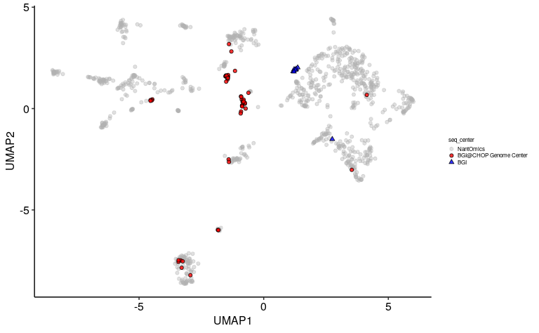

```r
ggplot(stranded_df) +
  aes(x = UMAP1, y = UMAP2,
      shape = seq_center,
      fill = seq_center,
      color = seq_center,
      alpha = seq_center) +
  geom_point() +
  scale_shape_manual(values = c(19, 21, 24)) +
  # first fill is ignored
  scale_fill_manual(values  = c("black", "red", "blue")) +
  scale_color_manual(values = c("grey70", "black", "black")) +
  scale_alpha_manual(values = c(0.4, 0.8, 0.8))
```

### Broad histology UMAP

We can make this finer-grained by exploring the distributions of broad histologies within this UMAP. Shapes denote the sequencing center, and colors denote the broad histology.

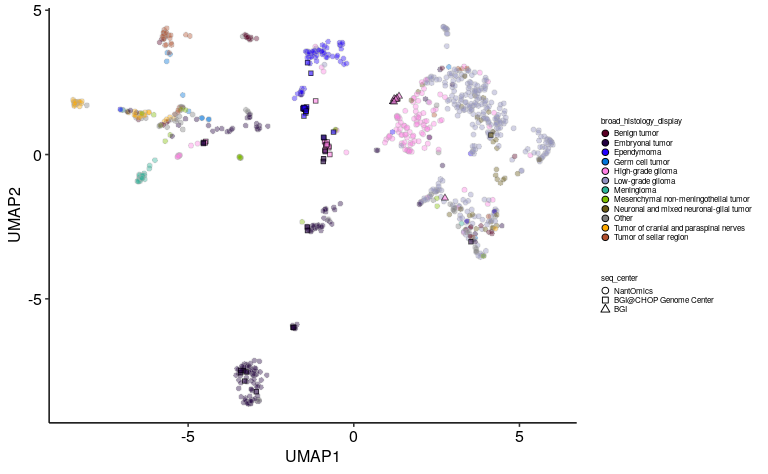

```r
ggplot(stranded_df) +
  aes(x = UMAP1, y = UMAP2,
      shape = seq_center,
      fill = broad_histology_display,
      color = seq_center,
      alpha = seq_center) +
  geom_point() +
  scale_shape_manual(values = c(21, 22, 24)) +
  scale_fill_manual(values  = pal_bh,
                    # This "shape" override is needed for legend fill colors to actually work
                    guide = guide_legend(override.aes = list(shape = 21, size = 2))) +
  scale_color_manual(values = c("grey70", "black", "black"),
                     # These overrides ensure shapes appear all in same alpha/color in legend
                     guide = guide_legend(override.aes = list(color = "black", alpha = 1, size = 2))) +
  scale_alpha_manual(values = c(0.4, 0.6, 0.6)) +
  # Legend tweaks for legibility
  theme(legend.position = "right",
        legend.direction = "vertical",
        legend.text = element_text(size = rel(0.5)),
        legend.title = element_text(size = rel(0.5)),
        legend.key.size = unit(0.25, "cm")
  )
```

We can also make this plot only for broad histologies which were processed at >1 center:

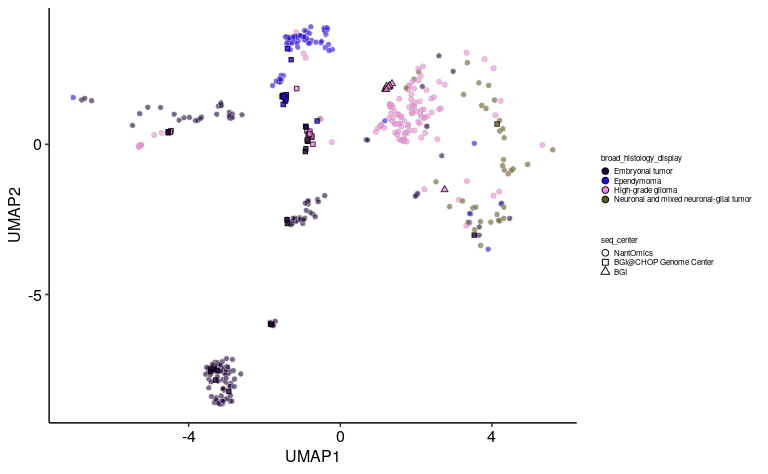

```r
# first, which histologies are shared, aka processed at >1 center?
shared_bh <- n_centers_bh %>%
  dplyr::filter(n > 1,
                RNA_library == "stranded") %>%
  dplyr::distinct(broad_histology_display) %>%
  dplyr::pull(broad_histology_display)


stranded_df %>%
  dplyr::filter(broad_histology_display %in% shared_bh) %>%
  ggplot() +
  aes(x = UMAP1, y = UMAP2,
      shape = seq_center,
      fill = broad_histology_display,
      color = seq_center,
      alpha = seq_center) +
  geom_point() +
  scale_shape_manual(values = c(21, 22, 24)) +
  scale_fill_manual(values  = pal_bh,
                    # This "shape" override is needed for legend fill colors to actually work
                    guide = guide_legend(override.aes = list(shape = 21, size = 2))) +
  scale_color_manual(values = c("grey70", "black", "black"),
                     # These overrides ensure shapes appear all in same alpha/color in legend
                     guide = guide_legend(override.aes = list(color = "black", alpha = 1, size = 2))) +
  scale_alpha_manual(values = c(0.6, 0.8, 0.8)) +
  # Legend tweaks for legibility
  theme(legend.position = "right",
        legend.direction = "vertical",
        legend.text = element_text(size = rel(0.5)),
        legend.title = element_text(size = rel(0.5)),
        legend.key.size = unit(0.25, "cm")
  )
```

### Cancer group UMAP

We can make this *even more* finer-grained by exploring the distributions of cancer groups within this UMAP. Shapes denote the sequencing center, and colors denote the cancer group. This plot will be exported, so we’ll save it to a variable as well.

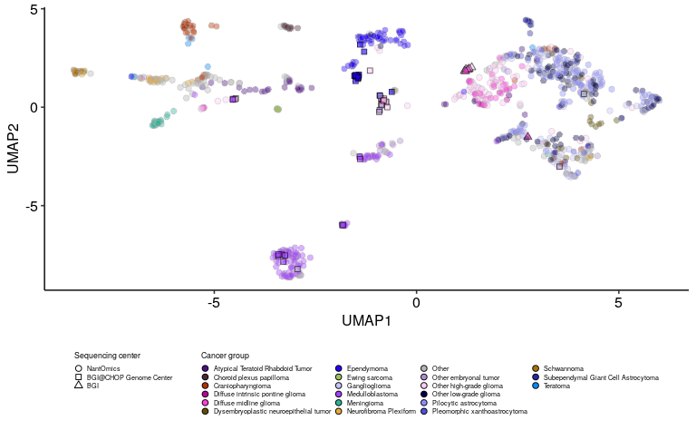

```r
cancer_group_umap_df <- stranded_df %>%
  tidyr::drop_na(cancer_group_display)

cancer_group_umap <- ggplot(cancer_group_umap_df) +
    aes(x = UMAP1, y = UMAP2,
        shape = seq_center,
        fill = cancer_group_display,
        color = seq_center,
        alpha = seq_center) +
    geom_point(size = 2) +
    scale_shape_manual(name = "Sequencing center",
                       values = c(21, 22, 24)) +
    scale_fill_manual(name = "Cancer group",
                      values  = pal_cg,
                      # This "shape" override is needed for legend fill colors to actually work
                      guide = guide_legend(override.aes = list(shape = 21),
                                           ncol = 4)) +
    # turn off color and alpha guides to avoid duplicate guides:
    scale_color_manual(values = c("grey70", "black", "black"), guide = "none") +
    scale_alpha_manual(values = c(0.4, 0.6, 0.6), guide = "none") +
    # Legend tweaks for legibility
    theme(legend.position = "bottom",
          legend.title = element_text(size = rel(0.55)),
          legend.text = element_text(size = rel(0.45)),
          legend.key.size = unit(0.25, "cm")
    )

# Print plot
cancer_group_umap
```

Now, we’ll export it:

```r
ggsave(
  cancer_group_umap_pdf,
  cancer_group_umap,
  width = 6.75,
  height = 5,
  # need for figure compilation
  useDingbats = FALSE
)
```

We will also export the underlying data for upload to Zenodo:

```r
cancer_group_umap_df %>%
  # reorder and subset columns and arrange
  dplyr::select(Kids_First_Biospecimen_ID, everything(),
                -contains("hex"), -contains("broad_histology")) %>%
  dplyr::arrange(Kids_First_Biospecimen_ID) %>%
  readr::write_csv(figS7c_csv)
```

We can also make this plot only for cancer groups which were processed at >1 center:

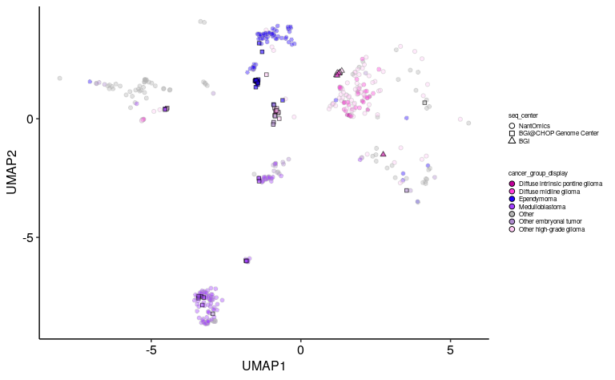

```r
# first, which histologies are shared, aka processed at >1 center?
shared_cg <- n_centers_cg %>%
  dplyr::filter(n > 1,
                RNA_library == "stranded") %>%
  dplyr::distinct(cancer_group_display) %>%
  dplyr::pull(cancer_group_display)


stranded_df %>%
  dplyr::filter(cancer_group_display %in% shared_cg) %>%
  ggplot() +
  aes(x = UMAP1, y = UMAP2,
      shape = seq_center,
      fill = cancer_group_display,
      color = seq_center,
      alpha = seq_center) +
  geom_point() +
  scale_shape_manual(values = c(21, 22, 24)) +
  scale_fill_manual(values  = pal_cg,
                    # This "shape" override is needed for legend fill colors to actually work
                    guide = guide_legend(override.aes = list(shape = 21, size = 2))) +
  scale_color_manual(values = c("grey70", "black", "black"),
                     # These overrides ensure shapes appear all in same alpha/color in legend
                     guide = guide_legend(override.aes = list(color = "black", alpha = 1, size = 2))) +
  scale_alpha_manual(values = c(0.4, 0.6, 0.6)) +
  # Legend tweaks for legibility
  theme(legend.position = "right",
        legend.direction = "vertical",
        legend.text = element_text(size = rel(0.5)),
        legend.title = element_text(size = rel(0.5)),
        legend.key.size = unit(0.25, "cm")
  )
```

## *Finer-grained* cancer group UMAP

We can also look at `cancer_group`, an *even finer* `cancer_group_display`. First we’ll set up with the other data frame, but we don’t a pre-defikned palette since there isn’t one for this grouping.

```r
# only keep stranded for the rest and set order for `seq_center` as group size
stranded_df <- umap_df_full %>%
  dplyr::filter(RNA_library == "stranded") %>%
  dplyr::select(-RNA_library) %>%
  dplyr::mutate(seq_center = forcats::fct_infreq(seq_center)) %>%
  # arranging will help see points:
  dplyr::arrange(seq_center)

# How many cancer groups are there in total?
total_cg <- unique(stranded_df$cancer_group)
length(total_cg)
```

```
[1] 59
```

```r
# How many cancer groups _processed at >1 center_ are there?
shared_cg_full <- n_centers_cg_full %>%
  dplyr::filter(n > 1,
                RNA_library == "stranded") %>%
  dplyr::distinct(cancer_group) %>%
  dplyr::pull(cancer_group)
length(shared_cg_full)
```

```
[1] 9
```

```r
shared_cg_full
```

```
[1] "CNS Embryonal tumor"                      "CNS neuroblastoma"
[3] "Diffuse intrinsic pontine glioma"         "Diffuse midline glioma"
[5] "Embryonal tumor with multilayer rosettes" "Ependymoma"
[7] "Glial-neuronal tumor NOS"                 "High-grade glioma astrocytoma"
[9] "Medulloblastoma"
```

Since there are 59 cancer groups, we’ll focus on visualizing only the 9 cancer groups that are processed at >1 center.

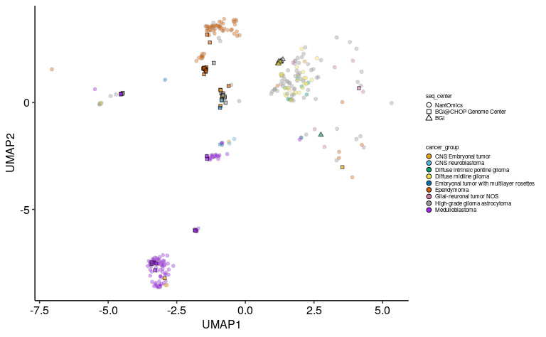

```r
stranded_df_subset <- stranded_df %>%
  dplyr::filter(cancer_group %in% shared_cg_full)

# plot itself:
cg_plot <- ggplot(stranded_df_subset) +
  aes(x = UMAP1, y = UMAP2,
      shape = seq_center,
      fill = cancer_group,
      color = seq_center,
      alpha = seq_center) +
  geom_point() +
  scale_fill_manual(values = c(colorblindr::palette_OkabeIto, "purple"), # needed a 9th color...........
                    # This "shape" override is needed for legend fill colors to actually work
                    guide = guide_legend(override.aes = list(shape = 21, size = 2))) +
  # Use a palette with 9 CVD-friendly colors
  scale_color_manual(values = c("grey70", "black", "black"),
                     # These overrides ensure shapes appear all in same alpha/color in legend
                     guide = guide_legend(override.aes = list(color = "black", alpha = 1, size = 2))) +
  scale_alpha_manual(values = c(0.4, 0.6, 0.6)) +
  scale_shape_manual(values = c(21, 22, 24))
cg_plot
```

## Conclusions

Overall, UMAP visualization shows that sequencing center is likely not a severe batch effect, and these visualizations emphasize that sequencing center is highly confounded with diagnosis making formal batch correction challenging.

That said, there does appear to be a group of samples with differing from BGI@CHOP which cluster together, which may be a batch-induced effect. In addition, there are a couple DMGs that cluster with MBs, though there are multiple sequencing centers in this “cluster.” Arrows are shown in the plot below pointing to these two caveated regions.

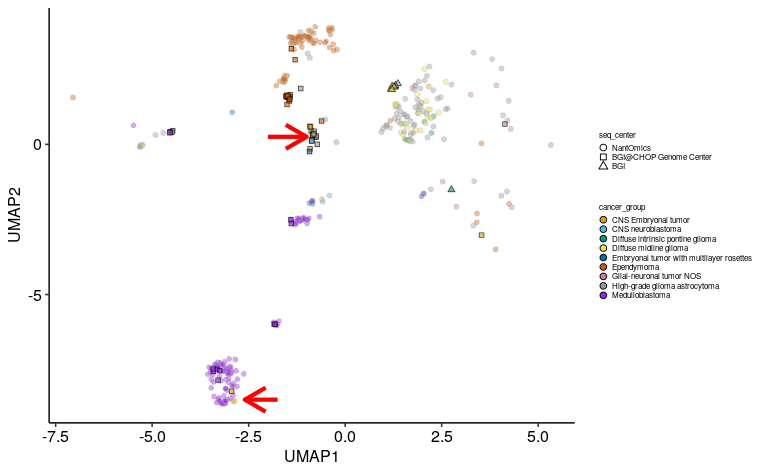

```r
cg_plot +
  annotate(
    "segment",
    x = -2, y = 0.25, xend = -1, yend = 0.25,
    color = "red", lwd=1.5,
    arrow = arrow()) +
  annotate(
    "segment",
    x = -1.75, y = -8.5, xend = -2.6,  yend = -8.5,
    color = "red", lwd=1.5,
    arrow = arrow())
```